# practiceQuestions(Answers)

```python
import pandas as pd
import numpy as np
```

```python
#Reading the CSV file
titanic1 = pd.read_csv("TITANIC.csv")
```

```python
#1
median_Fare = titanic1['Fare'].median()
print("Median fare: ${:.2f} ".format(median_Fare))
```

```
Median fare: $14.45
```

```python
#2
mean_Age_Of_Male = titanic1.loc[titanic1['Sex'] == 'male', 'Age'].mean()
print("Mean age: {:.2f} years".format(mean_Age_Of_Male))
```

```
Mean age: 30.27 years
```

```python
#3
mode_No_Of_Siblings = titanic1['SibSp'].mode()[0]
print("Mode of the no. of siblings/spouses aboard: {}".format(mode_No_Of_Siblings))
```

```
Mode of the no. of siblings/spouses aboard: 0
```

```python
#4
ticket_Price_Range = titanic1['Fare'].max() - titanic1['Fare'].min()
print("Range of ticket prices was: ${:.2f}".format(ticket_Price_Range))
```

```
Range of ticket prices was: $512.33
```

```python
#5
cheapest_Ticket_Cost = titanic1['Fare'].min()
print("Cost of cheapest ticket: ${:.2f}".format(cheapest_Ticket_Cost))
```

```
Cost of cheapest ticket: $0.00
```

```python
#6
correlation_Sex_Survival = titanic1['Sex'].astype('category').cat.codes.corr(titanic1['Survived'])
print("Correlation between Sex and Survival is: {:.2f}".format(correlation_Sex_Survival))
```

```
Correlation between Sex and Survival is: -1.00
```

```python
#7
variance_Passenger_Class = titanic1['Pclass'].var()
std_Dev_Passenger_Class = titanic1['Pclass'].std()
print("Variance: {:.2f}".format(variance_Passenger_Class))
print("Standard Deviation: {:.2f}".format(std_Dev_Passenger_Class))
```

```
Variance: 0.71
Standard Deviation: 0.84
```

# 8

# 1. Clearly displays the average age of male passengers

# 2. Demonstrates the most frequently occuring number of siblings/spouses aboard

# 3. Displays the spread between the cheapest and the most expensive tickets

# 4. This indicates the least ticket price

# 5. This demonstrates whether there is a connection between gender and survival

# 6. This measures the degree of the passenger class values' dispersion. More spread is indicated by a bigger variance

```python
#9
#Filling missing values with the mean of the column
titanic1['Age'].fillna(titanic1['Age'].mean())
```

```
0      34.50000
1      47.00000
2      62.00000
3      27.00000
4      22.00000
         ...
413    30.27259
414    39.00000
415    38.50000
416    30.27259
417    30.27259
Name: Age, Length: 418, dtype: float64
```

```python
#9
#Deleting rows with missing data
titanic1.dropna(axis=0)
```

|  | PassengerId | Survived | Pclass | Name | Sex | Age | SibSp | Parch | Ticket | Fare | Cabin | Embarked |
| --- | --- | --- | --- | --- | --- | --- | --- | --- | --- | --- | --- | --- |
| 12 | 904 | 1 | 1 | Snyder, Mrs. John Pillsbury (Nelle Stevenson) | female | 23.0 | 1 | 0 | 21228 | 82.2667 | B45 | S |
| 14 | 906 | 1 | 1 | Chaffee, Mrs. Herbert Fuller (Carrie Constance... | female | 47.0 | 1 | 0 | W.E.P. 5734 | 61.1750 | E31 | S |
| 24 | 916 | 1 | 1 | Ryerson, Mrs. Arthur Larned (Emily Maria Borie) | female | 48.0 | 1 | 3 | PC 17608 | 262.3750 | B57 B59 B63 B66 | C |
| 26 | 918 | 1 | 1 | Ostby, Miss. Helene Ragnhild | female | 22.0 | 0 | 1 | 113509 | 61.9792 | B36 | C |
| 28 | 920 | 0 | 1 | Brady, Mr. John Bertram | male | 41.0 | 0 | 0 | 113054 | 30.5000 | A21 | S |
| ... | ... | ... | ... | ... | ... | ... | ... | ... | ... | ... | ... | ... |
| 404 | 1296 | 0 | 1 | Frauenthal, Mr. Isaac Gerald | male | 43.0 | 1 | 0 | 17765 | 27.7208 | D40 | C |
| 405 | 1297 | 0 | 2 | Nourney, Mr. Alfred (Baron von Drachstedt")" | male | 20.0 | 0 | 0 | SC/PARIS 2166 | 13.8625 | D38 | C |
| 407 | 1299 | 0 | 1 | Widener, Mr. George Dunton | male | 50.0 | 1 | 1 | 113503 | 211.5000 | C80 | C |
| 411 | 1303 | 1 | 1 | Minahan, Mrs. William Edward (Lillian E Thorpe) | female | 37.0 | 1 | 0 | 19928 | 90.0000 | C78 | Q |
| 414 | 1306 | 1 | 1 | Oliva y Ocana, Dona. Fermina | female | 39.0 | 0 | 0 | PC 17758 | 108.9000 | C105 | C |

87 rows × 12 columns

```python
#11
#Identifying outliers in the dataset
Q1 = titanic1.quantile(0.25)
Q3 = titanic1.quantile(0.75)

#computing interquartile range
interquartileRange = Q3 - Q1

#Defining lower bounds and upper bounds to identify outliers
lowerBound = Q1 - 1.5 * interquartileRange
upperBound = Q3 + 1.5 * interquartileRange

#Identifying outliers
outliers = ((titanic1 < lowerBound) | (titanic1 > upperBound)).any(axis=1)

#Displaying rows containing outliers
print(titanic1[outliers])
```

```
     PassengerId  Survived  Pclass  \
4            896         1       3
7            899         0       2
12           904         1       1
21           913         0       3
23           915         0       1
..           ...       ...     ...
407         1299         0       1
409         1301         1       3
411         1303         1       1
414         1306         1       1
417         1309         0       3

                                                Name     Sex   Age  SibSp  \
4       Hirvonen, Mrs. Alexander (Helga E Lindqvist)  female  22.0      1
```

[output cut: 25 more lines]

```python
#10
#Checking for missing values
missing_values = titanic1.isnull().sum()
print("Missing values are:\n", missing_values)
```

```
Missing values are:
 PassengerId      0
Survived         0
Pclass           0
Name             0
Sex              0
Age             86
SibSp            0
Parch            0
Ticket           0
Fare             1
Cabin          327
Embarked         0
dtype: int64
```

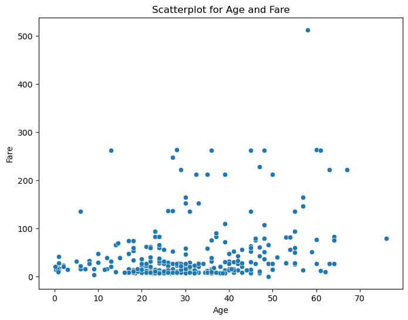

```python
#11
#Using scatter plot to visualize the data
import matplotlib.pyplot as plt
import seaborn as sns
plt.figure(figsize=(8, 6))
sns.scatterplot(x='Age', y='Fare', data=titanic1)
plt.title("Scatterplot for Age and Fare")
plt.show()
```

Scatter plots highlight the relationships between continuous variables, identifying outliers as data points deviationg significantly from the entire pattern, which assists in the provision of valuable insight into correlation between variables. Based on where they are in relation to other data points, scatter plots can be used to identify outliers. By observing points that are far from the primary cluster, it is possible to find outliers in the range of "age" to "fare".

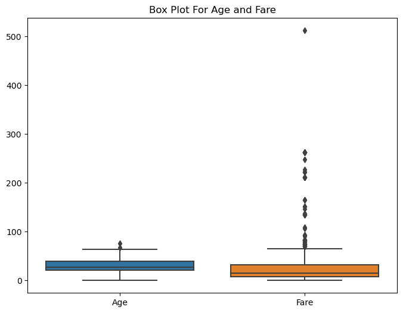

```python
#11
#Using boxplot to visualize the data
plt.figure(figsize=(8, 6))
sns.boxplot(data=titanic1[['Age', 'Fare']])
plt.title("Box Plot For Age and Fare")
plt.show()
```

Box plots examine the spread of features and locate outliers in each category to depict the data distribution and identify outliers within the Interquartile Range. They give a clear picture of the distribution of the data, making it easy to spot outliers and compare features such as 'age' and 'fare'.

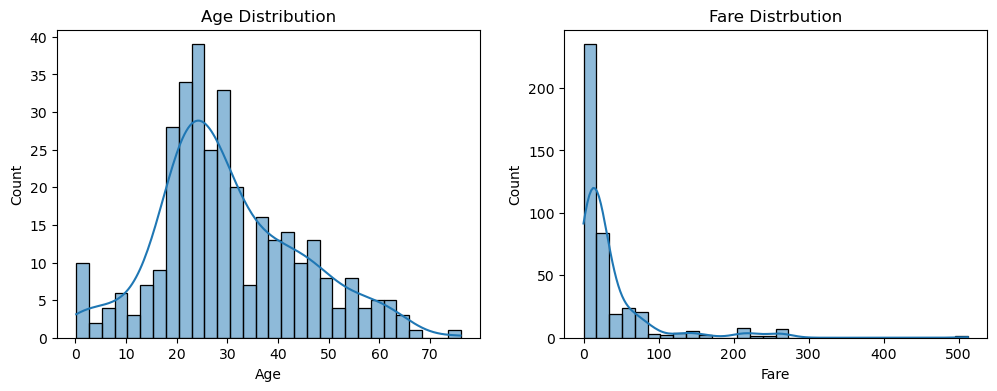

```python
#11
#Using histogram to visualize the data
plt.figure(figsize=(12, 4))
plt.subplot(1, 2, 1)
sns.histplot(titanic1['Age'], bins=30, kde=True)
plt.title("Age Distribution")
plt.subplot(1, 2, 2)
sns.histplot(titanic1['Fare'], bins=30, kde=True)
plt.title("Fare Distrbution")
plt.show()
```

Histograms display the continuous random variable visually, thus they can be used to spot outliers and areas with unusually high data densities by looking for odd peaks and gaps. By depicting age and fare, the presence of outliers can be identified.